# Probability Distributions for Health Technology Assessment

## What is a Probability Distribution?

A probability distribution is a mathematical function that describes the likelihood—or probability—of each possible outcome of a random experiment.

We can visualize this with two axes:

- **The X-Axis (Horizontal):** This represents all **possible values** that the variable can take. This could be clinical outcomes like cost, survival time, utility scores, or the number of adverse events.
- **The Y-Axis (Vertical):** This represents the **probability** (or relative likelihood) of each of those values occurring.

> **In short: A probability distribution defines how likely different future outcomes are.**

### A Simple Example: The Coin Flip

Imagine flipping a fair coin twice and counting the number of heads. The possible outcomes (X) are 0, 1, or 2 heads.

The probability distribution for this experiment is:

| Number of Heads (X) | Probability P(X) |
| --- | --- |
| 0 | 0.25 |
| 1 | 0.50 |
| 2 | 0.25 |

We can plot this. The x-axis would have the values 0, 1, and 2. The y-axis would show the probabilities 0.25, 0.50, and 0.25 as bars. This is a simple **discrete probability distribution**.

### Visualizing the Distribution

While the table is useful, it is often easier to understand a probability distribution by looking at its graph. The visual representation makes the “shape” of the distribution immediately clear.

Let’s plot the coin flip example using R’s `ggplot2` package, which is powerful for creating elegant and customizable graphics. For a discrete distribution like this, we use a **bar plot** (or a spike plot), where the height of each bar corresponds to the probability of each outcome.

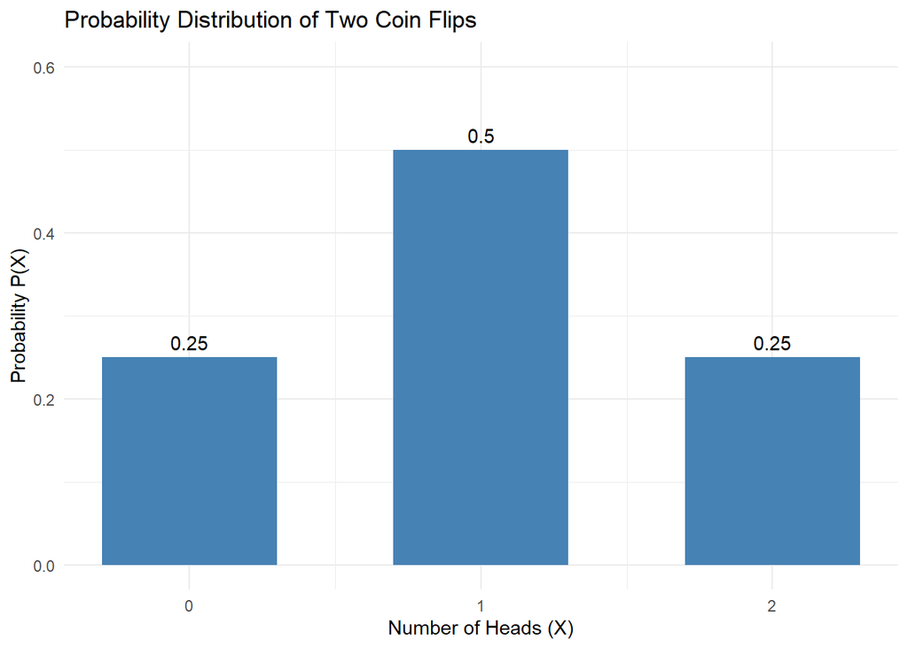

Bar plot of the probability distribution for the number of heads in two coin flips, created with ggplot2.

```r
library(ggplot2) # Load the ggplot2 package

# Create a data frame from our table
coin_data <- data.frame(
  Heads = c(0, 1, 2),           # X-axis values (Number of Heads)
  Probability = c(0.25, 0.50, 0.25) # Y-axis values (Probability)
)

# Create the plot using ggplot2
ggplot(data = coin_data, aes(x = Heads, y = Probability)) +
  geom_col(fill = "steelblue", width = 0.6) +      # Create bars
  geom_text(aes(label = Probability), vjust = -0.5) + # Add labels on top of bars
  scale_x_continuous(breaks = c(0, 1, 2)) +        # Ensure all values are on x-axis
  labs(title = "Probability Distribution of Two Coin Flips",
       x = "Number of Heads (X)",
       y = "Probability P(X)") +
  theme_minimal() +                                # Use a clean theme
  ylim(0, 0.6)                                     # Set the y-axis limits
```

## Types of Probability Distributions

### Discrete Probability Distributions

- These describe the probabilities of outcomes for countable, distinct values—such as 0, 1, 2, etc.
- The probability of each possible value is given by a probability mass function (PMF).

Major discrete distributions in health data include:

| Distribution | PMF, $P(X=k)$ | Parameters |
| --- | --- | --- |
| **Bernoulli** | $p^k (1-p)^{1-k}$ | `prob` ($p$) |
| **Binomial** | $\binom{n}{k} p^k (1-p)^{n-k}$ | `size` ($n$), `prob` ($p$) |
| **Poisson** | $\frac{\lambda^k e^{-\lambda}}{k!}$ | `lambda` ($\lambda$) |
| **Negative Binomial** | $\binom{k + r - 1}{k} p^r (1-p)^k$ | `size` ($r$), `prob` ($p$) |

### Continuous Probability Distributions

- These describe probabilities for any value within an interval (not just whole numbers, but all real values within a range).
- The probability is given by a probability density function (PDF); probabilities refer to intervals, not exact values.

Major continuous distributions in health and medical research include:

| Distribution | PDF, $f(x)$ | Parameters |
| --- | --- | --- |
| **Normal** | $\frac{1}{\sigma\sqrt{2\pi}} e^{-\frac{1}{2}\left(\frac{x-\mu}{\sigma}\right)^2}$ | `mean` ($\mu$), `sd` ($\sigma$) |
| **Log-Normal** | $\frac{1}{x\sigma\sqrt{2\pi}} e^{-\frac{(\ln x - \mu)^2}{2\sigma^2}}$ | `meanlog` ($\mu$), `sdlog` ($\sigma$) |
| **Exponential** | $\lambda e^{-\lambda x}$ | `rate` ($\lambda$) |
| **Gamma** | $\frac{\beta^{\alpha}}{\Gamma(\alpha)} x^{\alpha-1} e^{-\beta x}$ | `shape` ($\alpha$), `rate` ($\beta$) |
| **Weibull** | $\frac{k}{\lambda} \left( \frac{x}{\lambda} \right)^{k-1} e^{-(x/\lambda)^k}$ | `shape` ($k$), `scale` ($\lambda$) |
| **Beta** | $\frac{x^{\alpha-1}(1-x)^{\beta-1}}{B(\alpha, \beta)}$ | `shape1` ($\alpha$), `shape2` ($\beta$) |

## Parameters of Probability Distributions

Now that you have seen the mathematical equations defining different probability distributions, you might have noticed many terms inside these formulas—like $\mu$, $\sigma$, $\lambda$, $\alpha$, and $k$. These terms are called the parameters of a distribution.

### Why Are Parameters Important?

- The shape or curve of each probability distribution is determined by the values of these parameters.
- They control where the distribution is centered, how spread out it is, and how it is skewed or shaped.
- Although the formulas might look complicated at first, understanding these parameters gives you a powerful way to describe and work with uncertainty in Health Technology Assessment.

### Three Major Types of Parameters

Most distributions have some combination of these key parameter types:

- **Location Parameter ($\mu$, mean):** Defines the “center” or position of the distribution on the x-axis.
- **Scale Parameter ($\sigma$, variance):** Defines the spread or variability of the distribution.
- **Shape Parameter ($k$, $\alpha$, $\beta$):** Controls the overall form or peakness/skewness of the distribution.

> **Note:** Not all distributions require all three parameter types. Some have additional or transformed parameters (e.g., the `rate` in an Exponential distribution), but the broad concepts of location, scale, and shape cover most cases.

### Detailed Examples of Parameter Types

#### 1. Location Parameter ($\mu$)

A location parameter shifts the entire distribution along the x-axis without changing its spread or shape.

**Example: Normal Distribution with Constant Scale**

Two Normal distributions with the same standard deviation ($\sigma = 1$) but different means:

- $N(\mu=0, \sigma=1)$ is centered at 0
- $N(\mu=2, \sigma=1)$ is centered at 2

The change in $\mu$ moves the center of the bell curve.

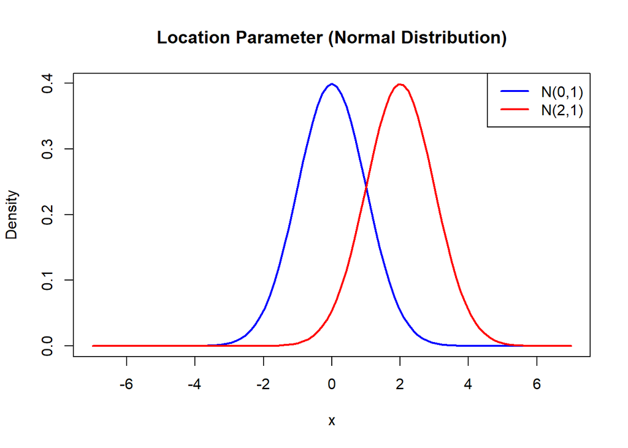

```r
curve(dnorm(x, mean = 0, sd = 1), from = -7, to = 7, col = "blue", lwd = 2, ylab = "Density", xlab = "x", main = "Location Parameter (Normal Distribution)")
curve(dnorm(x, mean = 2, sd = 1), col = "red", lwd = 2, add = TRUE)
legend("topright", legend = c("N(0,1)", "N(2,1)"), col = c("blue", "red"), lwd = 2)
```

#### 2. Scale Parameter ($\sigma$)

A scale parameter stretches or squeezes the distribution, changing its spread without changing its location or fundamental shape.

**Example: Normal Distribution with Constant Location** Two Normal distributions with the same mean ($\mu = 0$) but different standard deviations: - $N(\mu=0, \sigma=1)$ is narrow and tall - $N(\mu=0, \sigma=2)$ is wide and short The change in $\sigma$ alters the variability.

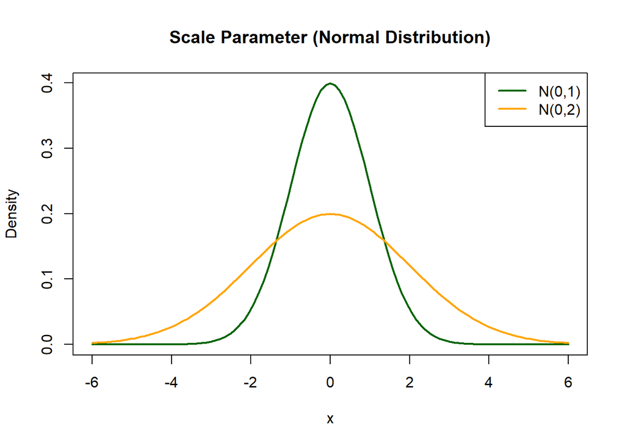

```r
curve(dnorm(x, mean = 0, sd = 1), from = -6, to = 6, col = "darkgreen", lwd = 2, ylab = "Density", xlab = "x", main = "Scale Parameter (Normal Distribution)")
curve(dnorm(x, mean = 0, sd = 2), col = "orange", lwd = 2, add = TRUE)
legend("topright", legend = c("N(0,1)", "N(0,2)"), col = c("darkgreen", "orange"), lwd = 2)
```

> The Normal distribution does not have a separate shape parameter. Its symmetric bell curve shape is constant and determined solely by $\mu$ and $\sigma$.

#### 3. Shape Parameter ($\alpha$, $\beta$)

Shape parameters control the fundamental form of the distribution, such as its skewness or peakedness.

**Example: Beta Distribution** The Beta distribution uses two shape parameters ($\alpha$, $\beta$):

- $\alpha = \beta = 1$: Uniform distribution
- $\alpha < \beta$: Right-skewed distribution
- $\alpha > \beta$: Left-skewed distribution
- $\alpha = \beta > 1$: Bell-shaped and symmetric Changing $\alpha$ and $\beta$ fundamentally alters the distribution’s shape.

**Chunk 3: Shape Parameter Plot**

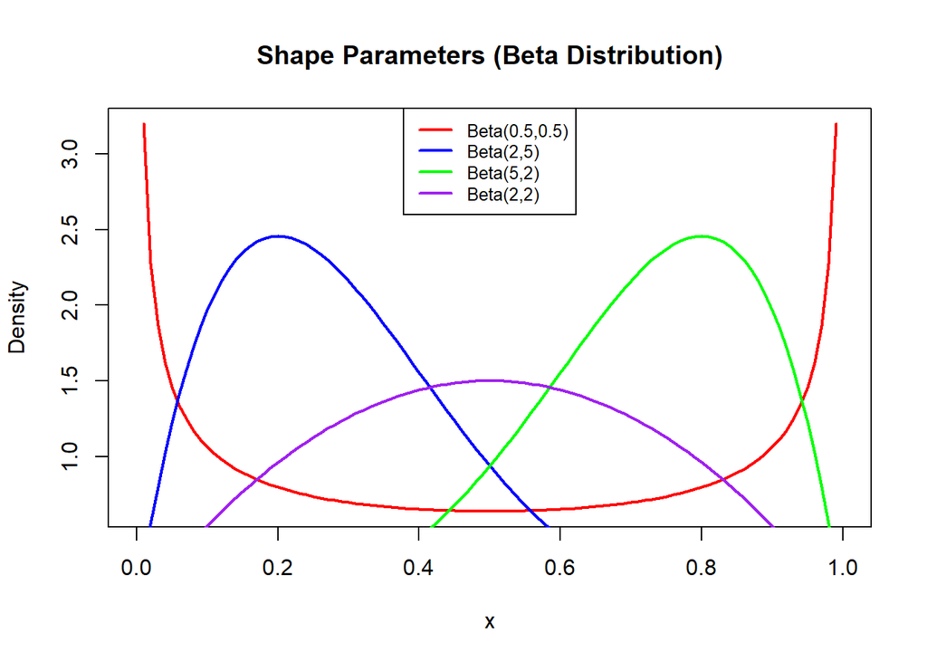

```r
curve(dbeta(x, shape1 = 0.5, shape2 = 0.5), from = 0, to = 1, col = "red", lwd = 2, ylab = "Density", xlab = "x", main = "Shape Parameters (Beta Distribution)")
curve(dbeta(x, shape1 = 2, shape2 = 5), col = "blue", lwd = 2, add = TRUE)
curve(dbeta(x, shape1 = 5, shape2 = 2), col = "green", lwd = 2, add = TRUE)
curve(dbeta(x, shape1 = 2, shape2 = 2), col = "purple", lwd = 2, add = TRUE)
legend("top", legend = c("Beta(0.5,0.5)", "Beta(2,5)", "Beta(5,2)", "Beta(2,2)"),
       col = c("red", "blue", "green", "purple"), lwd = 2, cex = 0.8)
```

## Transforming Mean and SD into Distribution Parameters

In HTA, we often only have summary statistics (mean and standard deviation) for a parameter. The following formulas are used to estimate the parameters of common distributions for probabilistic sensitivity analysis.

| Distribution | Parameters to Find | Conversion Formulas |
| --- | --- | --- |
| **Normal** | `mean` ($\mu$), `sd` ($\sigma$) | $\mu = \bar{x}$ $\sigma = s$ |
| **Gamma** | `shape` ($\alpha$), `rate` ($\beta$) | $\alpha = \frac{\bar{x}^2}{s^2}$ $\beta = \frac{\bar{x}}{s^2}$ |
| **Log-Normal** | `meanlog` ($\mu$), `sdlog` ($\sigma$) | $\mu = \ln\left(\frac{\bar{x}^2}{\sqrt{s^2 + \bar{x}^2}}\right)$ $\sigma = \sqrt{\ln\left(1 + \frac{s^2}{\bar{x}^2}\right)}$ |
| **Beta** | `shape1` ($\alpha$), `shape2` ($\beta$) | $\alpha = \bar{x} \left( \frac{\bar{x}(1-\bar{x})}{s^2} - 1 \right)$ $\beta = (1 - \bar{x}) \left( \frac{\bar{x}(1-\bar{x})}{s^2} - 1 \right)$ |

Where: - $\bar{x}$ = sample mean - $s$ = sample standard deviation - $s^2$ = sample variance

> **Important Note for Beta Distribution:** The formulas for the Beta distribution assume the data represents proportions bounded between 0 and 1. Ensure your mean and SD are appropriate for this scale.

## When to Use Each Distribution in HTA

Different types of data in HTA require different probability distributions for accurate modeling. Here’s a guide based on outcome types:

| Data Type | Common Distributions | Notes on Use |
| --- | --- | --- |
| **Binary Outcomes** | Bernoulli, Binomial | Models presence/absence (e.g., treatment success/failure) |
| **Counts of Events** | Poisson, Negative Binomial | Number of adverse events, hospital visits; Negative Binomial handles overdispersion |
| **Continuous Measurements** | Normal, Log-normal, Gamma, Weibull | Biomarkers, costs, survival times; Log-normal and Gamma handle skewed data |
| **Time-to-event Data** | Exponential, Weibull | Models survival times, waiting times, or time to relapse |
| **Proportions/Fractions** | Beta | Health utilities, probabilities constrained between 0 and 1 |

## Working with Distributions in R

R provides a consistent set of functions for working with probability distributions, following a standard naming pattern:

### The Four Key Functions

| Prefix | Purpose | Example (Normal) |
| --- | --- | --- |
| **`d`** | Density or Probability Mass Function (PDF/PMF) | `dnorm(x, mean, sd)` |
| **`p`** | Cumulative Distribution Function (CDF) | `pnorm(q, mean, sd)` |
| **`q`** | Quantile Function (Inverse CDF) | `qnorm(p, mean, sd)` |
| **`r`** | Random Number Generation | `rnorm(n, mean, sd)` |

### Common Distribution Functions

This pattern applies to all major distributions:

| Distribution | Density/PMF | CDF | Quantile | Random |
| --- | --- | --- | --- | --- |
| **Normal** | `dnorm()` | `pnorm()` | `qnorm()` | `rnorm()` |
| **Binomial** | `dbinom()` | `pbinom()` | `qbinom()` | `rbinom()` |
| **Poisson** | `dpois()` | `ppois()` | `qpois()` | `rpois()` |
| **Exponential** | `dexp()` | `pexp()` | `qexp()` | `rexp()` |
| **Gamma** | `dgamma()` | `pgamma()` | `qgamma()` | `rgamma()` |
| **Beta** | `dbeta()` | `pbeta()` | `qbeta()` | `rbeta()` |
| **Weibull** | `dweibull()` | `pweibull()` | `qweibull()` | `rweibull()` |
| **Log-normal** | `dlnorm()` | `plnorm()` | `qlnorm()` | `rlnorm()` |
| **Negative Binomial** | `dnbinom()` | `pnbinom()` | `qnbinom()` | `rnbinom()` |

### Example Usage

#### Probability of exactly 2 successes in 5 trials with p=0.5

```r
dbinom(2, size = 5, prob = 0.5)
```

```
[1] 0.3125
```

#### Probability of ≤3 adverse events when λ=2

```r
ppois(3, lambda = 2)
```

```
[1] 0.8571235
```

#### 95th percentile of Normal(0,1)

```r
qnorm(0.95, mean = 0, sd = 1)
```

```
[1] 1.644854
```

#### Generate 10 random costs from Gamma(shape=2, rate=0.1)

```r
rgamma(10, shape = 2, rate = 0.1)
```

```
 [1] 26.221904 12.200817 14.863575  8.827533 39.415386  3.231701 11.057500
 [8] 26.907655 30.696813 12.367086
```

## Visualizing Distributions with `curve()`

The `curve()` function is useful for visualizing the probability density function (PDF) or probability mass function (PMF) of a distribution.

### 1. Normal Distribution

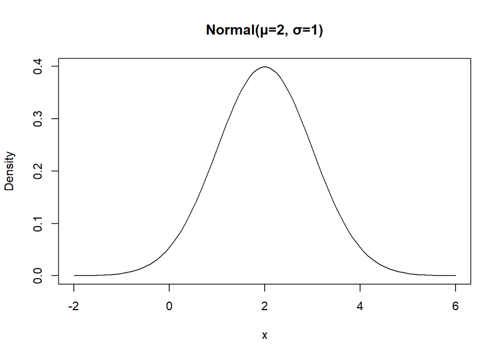

```r
curve(dnorm(x, mean = 2, sd = 1), from = -2, to = 6, main = "Normal(μ=2, σ=1)", ylab = "Density", xlab = "x")
```

### 2. Gamma Distribution

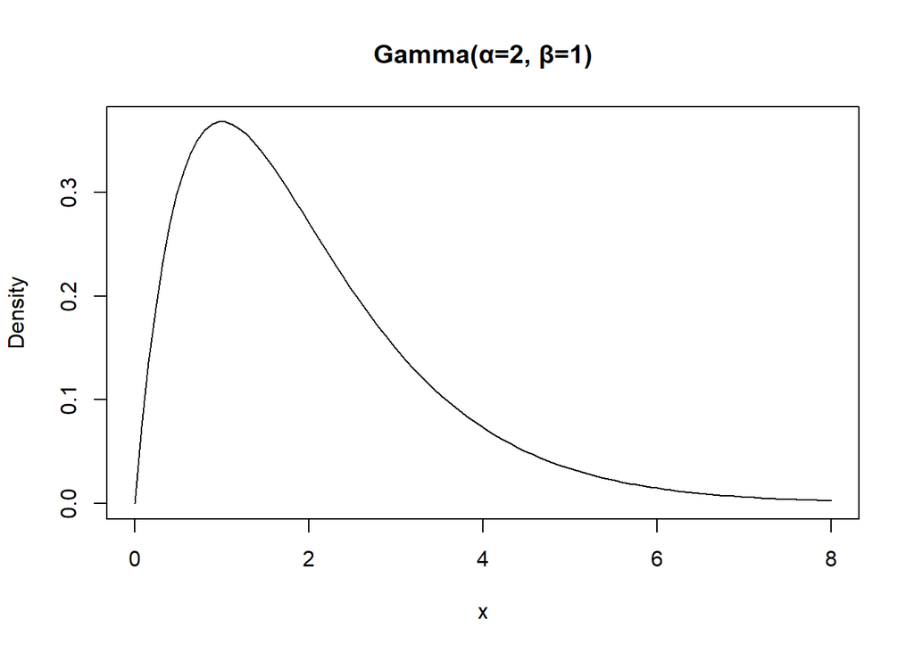

```r
curve(dgamma(x, shape = 2, rate = 1), from = 0, to = 8, main = "Gamma(α=2, β=1)", ylab = "Density", xlab = "x")
```

### 3. Beta Distribution

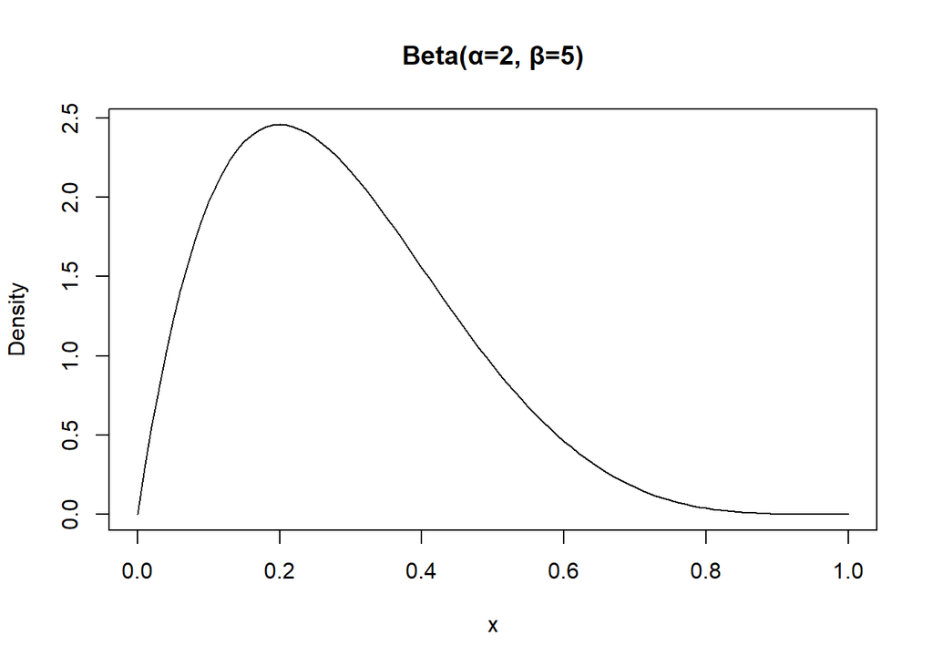

```r
curve(dbeta(x, shape1 = 2, shape2 = 5), from = 0, to = 1, main = "Beta(α=2, β=5)", ylab = "Density", xlab = "x")
```

### 4. Exponential Distribution

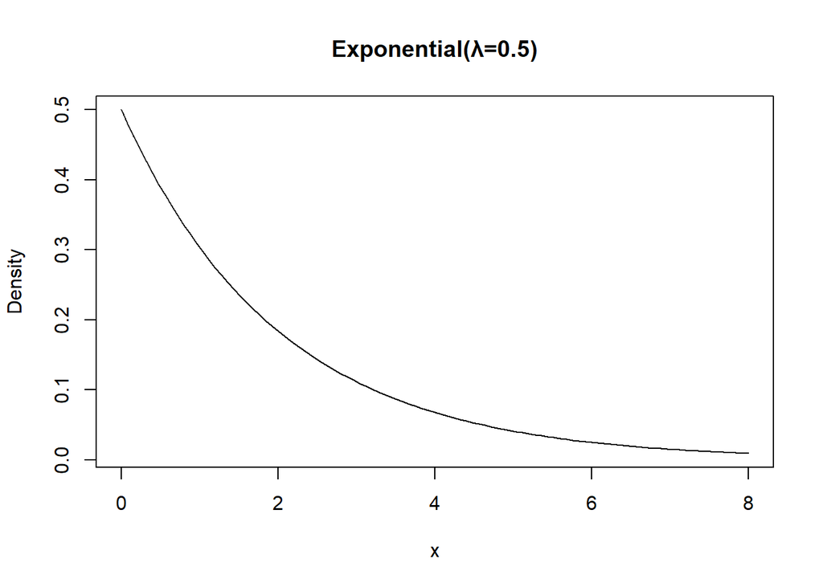

```r
curve(dexp(x, rate = 0.5), from = 0, to = 8, main = "Exponential(λ=0.5)", ylab = "Density", xlab = "x")
```

### 5. Weibull Distribution

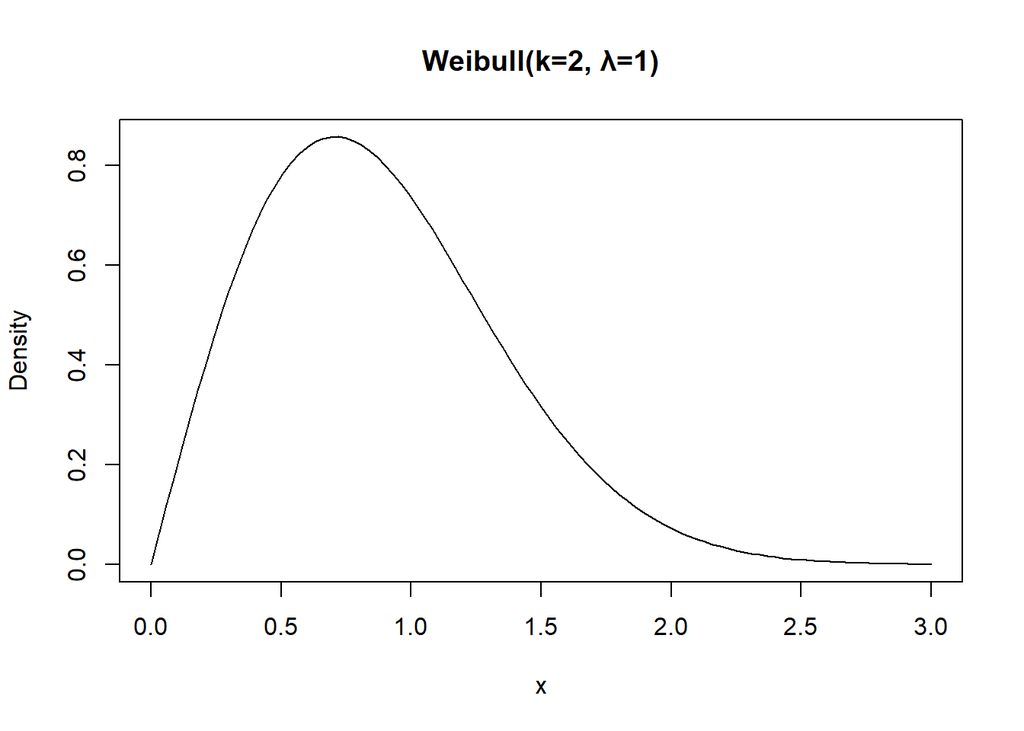

```r
curve(dweibull(x, shape = 2, scale = 1), from = 0, to = 3, main = "Weibull(k=2, λ=1)", ylab = "Density", xlab = "x")
```

### 6. Log-Normal Distribution

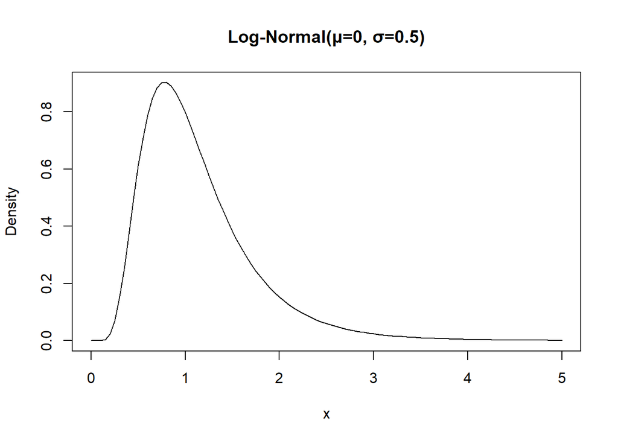

```r
curve(dlnorm(x, meanlog = 0, sdlog = 0.5), from = 0, to = 5, main = "Log-Normal(μ=0, σ=0.5)", ylab = "Density", xlab = "x")
```

### 7. Binomial Distribution (PMF)

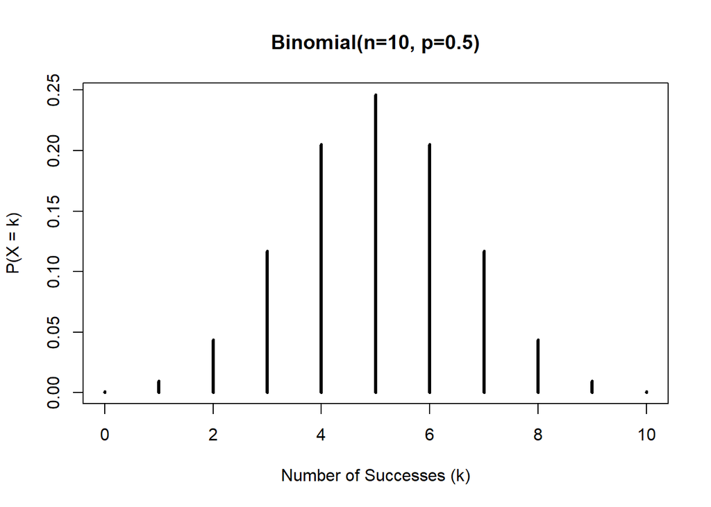

```r
x <- 0:10
plot(x, dbinom(x, size = 10, prob = 0.5), type = "h", lwd = 3,
     main = "Binomial(n=10, p=0.5)", ylab = "P(X = k)", xlab = "Number of Successes (k)")
```

### 8. Poisson Distribution (PMF)

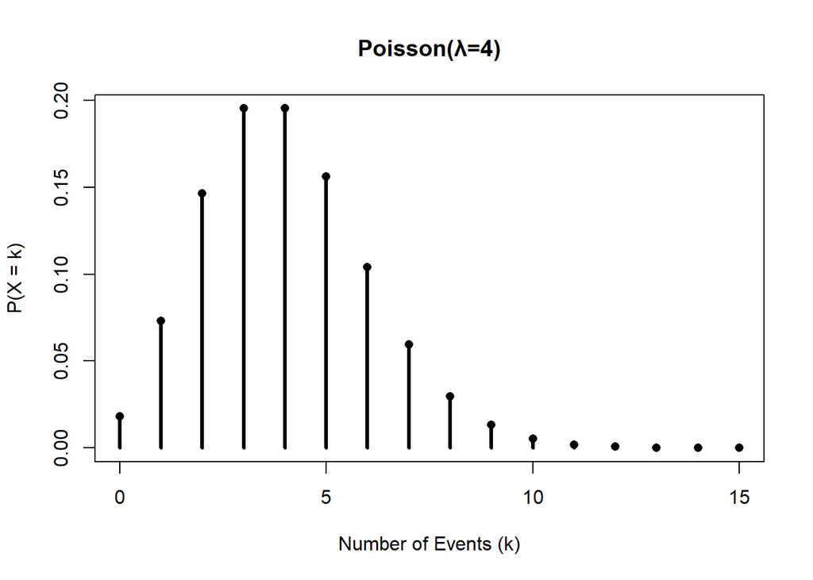

```r
x <- 0:15
plot(x, dpois(x, lambda = 4), type = "h", lwd = 3, main = "Poisson(λ=4)", ylab = "P(X = k)", xlab = "Number of Events (k)")
points(x, dpois(x, lambda = 4), pch = 16)
```

### 9. Negative Binomial Distribution (PMF)

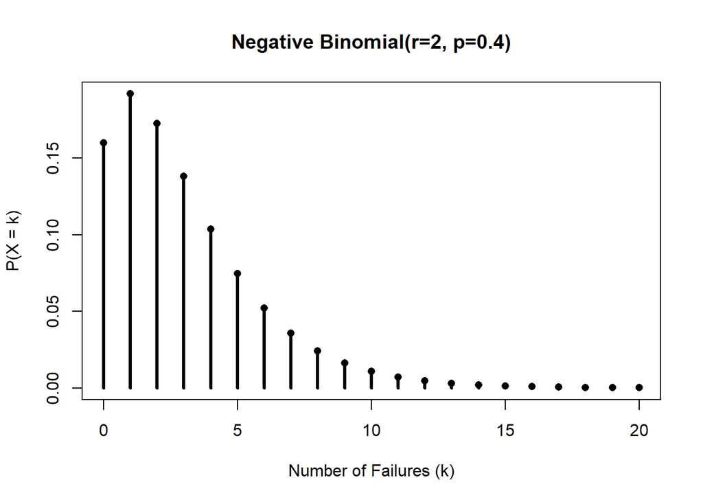

```r
x <- 0:20
plot(x, dnbinom(x, size = 2, prob = 0.4), type = "h", lwd = 3,
     main = "Negative Binomial(r=2, p=0.4)", ylab = "P(X = k)", xlab = "Number of Failures (k)")
points(x, dnbinom(x, size = 2, prob = 0.4), pch = 16)
```

## Case Study

### Data

```r
library(tidyverse)
library(here)

df <- readxl::read_excel(here("data", "distributions_hta_casestudy.xlsx"))

kableExtra::kable(df, format.args = list(big.mark = ",", scientific = FALSE))
```

| variable | root_definition | distribution |
| --- | --- | --- |
| cost_annualmaintenance | 150,000.0000000 | Gamma |
| cost_icuday | 9,350.0000000 | Gamma |
| cost_ip_day | 2,300.0000000 | Gamma |
| cost_pcv13 | 3,955.0000000 | Gamma |
| cost_vaccination_transport | 100.0000000 | Gamma |
| cost_vaccineadministration | 116.0000000 | Gamma |
| hospitaldays_Ipd | 19.9000000 | Gamma |
| hospitaldays_Npp | 12.0000000 | Gamma |
| icudays_ipd | 9.0000000 | Gamma |
| icudays_npp | 6.0000000 | Gamma |
| initprob_highrisk | 1.0000000 | LogN |
| prob_death | 0.0091000 | LogN |
| prob_deathippneumonia | 0.0136000 | LogN |
| prob_ipddisabled | 0.0128000 | LogN |
| prob_ippneumonia | 0.0035997 | LogN |
| prob_meningitis | 0.0000212 | LogN |
| prob_meningitisdeath | 0.1538000 | LogN |
| prob_nppdisabled | 0.0064000 | LogN |
| prob_oppneumonia | 0.0169631 | LogN |
| prob_sepsis | 0.0000630 | LogN |
| prob_sepsisdeath | 0.1681000 | LogN |
| prop_icu_ipd | 0.3100000 | LogN |
| prop_icu_npp | 0.1530000 | LogN |
| u_disabled | 0.3000000 | Beta |
| u_general | 0.9283000 | Beta |

### Transforming Data

```r
owsa_range <- 0.2

df <- df |>
  mutate(
    low = round((1 - owsa_range) * root_definition, 4),
    high = round((1 + owsa_range) * root_definition, 4),
    se = round( (high - low) / (2 * qnorm(0.975)), 4)
  )

df <- df |>
  mutate(
    # Calculate alpha and beta for Gamma/Beta, meanlog and sdlog for LogN
    param1 = case_when(
      distribution == "Gamma" ~ (root_definition^2) / (se^2),
      distribution == "Beta" ~ root_definition * ( (root_definition*(1-root_definition)/(se^2)) - 1 ),
      distribution == "LogN" ~ log(root_definition^2 / sqrt(se^2 + root_definition^2)),
      TRUE ~ NA_real_
    ),
    param2 = case_when(
      distribution == "Gamma" ~ root_definition / (se^2),
      distribution == "Beta" ~ (1 - root_definition) * ( (root_definition*(1-root_definition)/(se^2)) - 1 ),
      distribution == "LogN" ~ sqrt(log(1 + (se^2 / root_definition^2))),
      TRUE ~ NA_real_
    ),
    # Create the formatted parameter strings for R with correct argument names
    parameters = case_when(
      distribution == "Gamma" ~ paste0("shape = ", round(param1, 4), ", rate = ", round(param2, 6)),
      distribution == "Beta" ~ paste0("shape1 = ", round(param1, 4), ", shape2 = ", round(param2, 4)),
      distribution == "LogN" ~ paste0("meanlog = ", round(param1, 4), ", sdlog = ", round(param2, 4)),
      TRUE ~ "Distribution not specified"
    )
  )
```

### Sampling and Visualising Distributions

#### For Gamma Distribution

```r
df |>
  filter(distribution == "Gamma") |>
  slice(1) |>
  select(parameters)
```

```
# A tibble: 1 × 1
  parameters
  <chr>
1 shape = 96.0365, rate = 0.00064
```

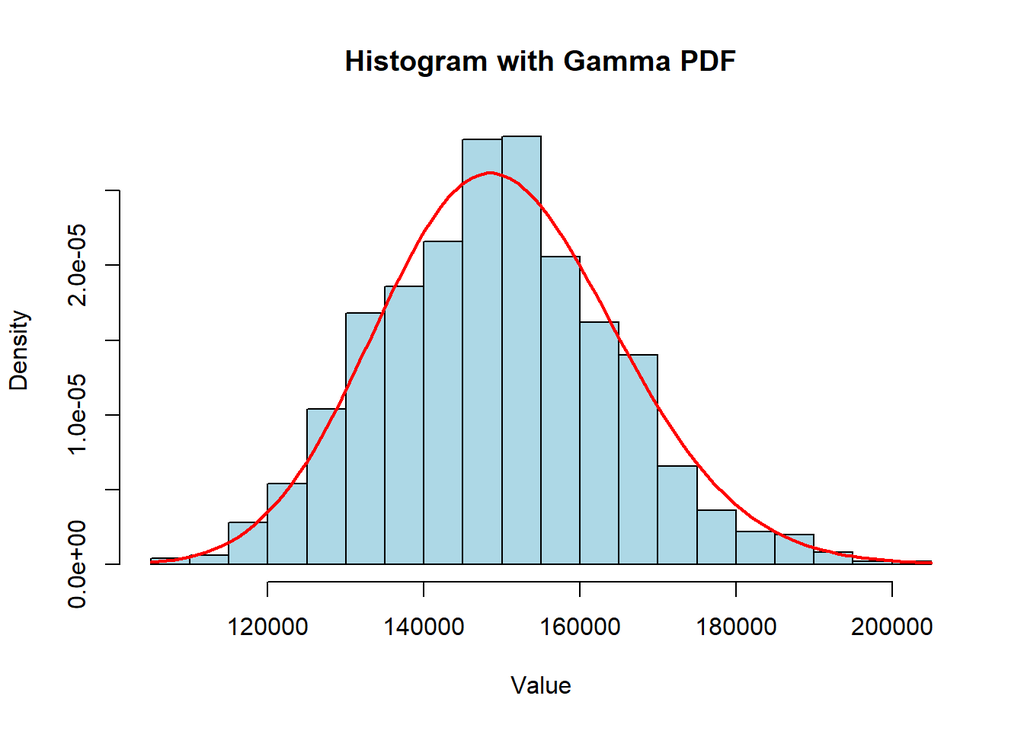

```r
set.seed(123)
samples_gamma <- rgamma(1000, shape = 96.0365, rate = 0.00064)

hist(samples_gamma, probability = TRUE, breaks = 30, col = "lightblue",
     main = "Histogram with Gamma PDF", xlab = "Value")
curve(dgamma(x, shape = 96.0365, rate = 0.00064), col = "red", add = TRUE, lwd = 2)
```

#### For Beta Distribution

```r
df |>
  filter(distribution == "Beta") |>
  slice(1) |>
  select(parameters)
```

```
# A tibble: 1 × 1
  parameters
  <chr>
1 shape1 = 66.9818, shape2 = 156.2909
```

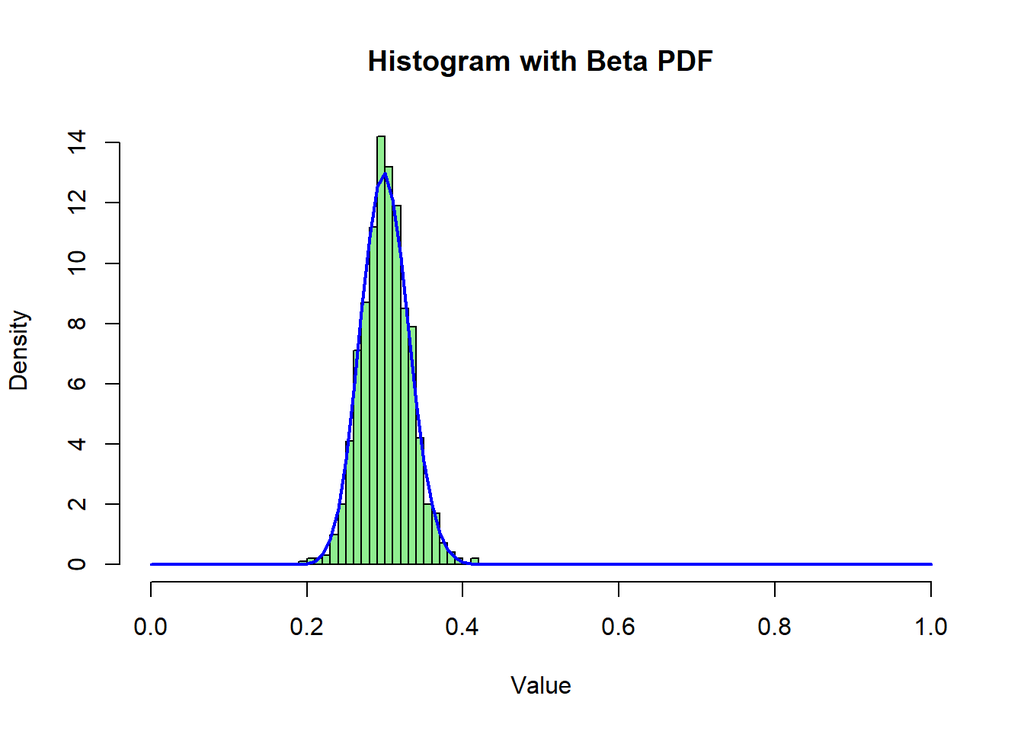

```r
set.seed(123)
samples_beta <- rbeta(1000, shape1 = 66.9818, shape2 = 156.2909)

hist(samples_beta, probability = TRUE, breaks = 30, col = "lightgreen",
     main = "Histogram with Beta PDF", xlab = "Value", xlim = c(0,1))
curve(dbeta(x, shape1 = 66.9818, shape2 = 156.2909), col = "blue", add = TRUE, lwd = 2)
```

#### For Log Normal Distribution

```r
df |>
  filter(distribution == "LogN") |>
  slice(1) |>
  select(parameters)
```

```
# A tibble: 1 × 1
  parameters
  <chr>
1 meanlog = -0.0052, sdlog = 0.1017
```

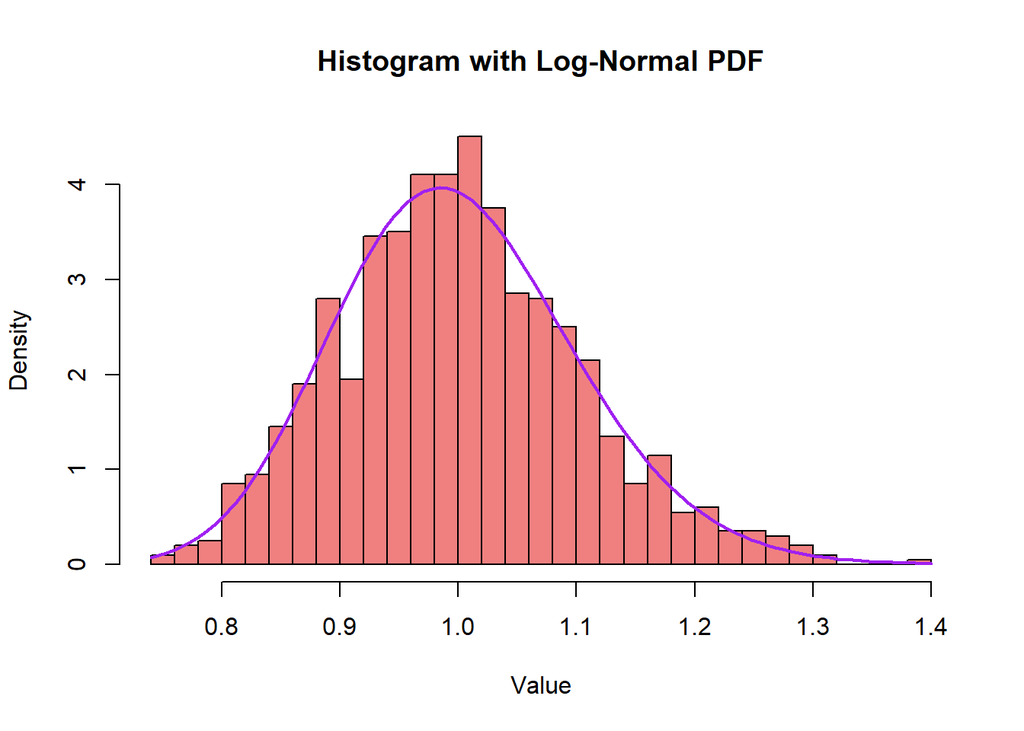

```r
set.seed(123)
samples_lnorm <- rlnorm(1000, meanlog = -0.0052, sdlog = 0.1017) # Use your calculated param1 & param2

hist(samples_lnorm, probability = TRUE, breaks = 30, col = "lightcoral",
     main = "Histogram with Log-Normal PDF", xlab = "Value")
curve(dlnorm(x, meanlog = -0.0052, sdlog = 0.1017), col = "purple", add = TRUE, lwd = 2)
```